# tidyverse 1.2.0

Mara Averick

2017-11-15

The release of [tidyverse 1.2.0](https://github.com/tidyverse/tidyverse/releases) on CRAN (now 1.2.1, following some minor fixes) includes updates in tidyverse package membership, as well as to tidyverse functions themselves.

The latest version of tidyverse can be installed with:

```r
install.packages("tidyverse")
```

## Changes in tidyverse membership

### Addition of the reprex package

Though it’s been a mainstay tidyverse [Help](https://www.tidyverse.org/help/), 1.2.0 marks the official addition of [reprex](http://reprex.tidyverse.org/) (short for **repr**oducible **ex**ample) to the tidyverse.

The goal of a reprex is to package your problematic code in such a way that other people can run it and feel your pain. Think of every request for a reprex as a plea to *“help me help you!”*

This update includes reprex **Addins**, accessible from the RStudio drop-down menu.

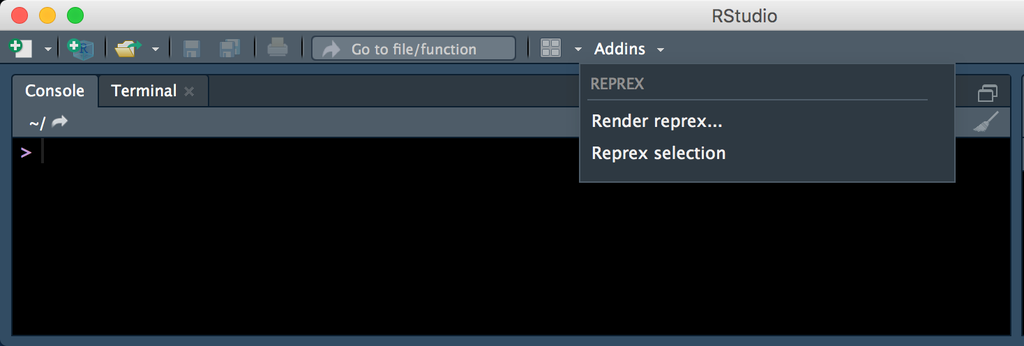

### Updates to tidyverse core

The [stringr](http://stringr.tidyverse.org/) and [forcats](http://forcats.tidyverse.org/) packages (for string, and categorical variable manipulation, respectively) have joined [ggplot2](http://ggplot2.tidyverse.org/), [dplyr](http://dplyr.tidyverse.org/), [tidyr](http://tidyr.tidyverse.org/), [readr](http://readr.tidyverse.org/), [purrr](http://purrr.tidyverse.org/), and [tibble](http://tibble.tidyverse.org/) to make up the core tidyverse.

Running `library(tidyverse)` attaches these core packages in the current R session. On attach, tidyverse now makes better use of horizontal space, printing packages and versions in two columns (see below). Additionally, packages that have already been attached are not be printed, and development versions are highlighted in red. The startup message can now be suppressed with `options(tidyverse.quiet = TRUE)`.

[figure not shown]

## Other improvements

While a comprehensive list of changes can be found in the [release notes](https://github.com/tidyverse/tidyverse/releases), other highlights include:

- `tidyverse_conflicts()` now prints all conflicts involving at least one tidyverse package (including intra-tidyverse conflicts, omitted in previous versions)
- Addition of a `tidyverse_logo()` function.

[figure not shown]